# Vignette-sparseDGLM

# Introduction

This vignette demonstrates the use of the `sparseDGLM` package for sparse spatio-temporal dynamic generalized linear models (DGLMs) for bicycle count data.

The model for $Y_{t}(s)$ consists of a Poisson likelihood for the observed counts and a latent spatiotemporal process for the log-intensity $\lambda_t(s)$, which is decomposed into a spatiotemporal varying intercept, a temporal component modeled using harmonic matrices, space-time invariant covariate, and a spatiotemporal error term.

The error term in the space-time varying component is modeled using a Gaussian process with a Matérn covariance structure, which captures spatial dependencies at time $t$. The package supports Gaussian processes with both dense covariance and sparse precision matrices.

A customized MCMC sampler is implemented to perform Bayesian inference for the model parameters, including the spatiotemporal intercepts, space-time invariant covariate effects, and hyperparameters governing the spatial and temporal dependencies.

This package also provides function to perform predictions for unobserved time points and spatial locations, allowing users to leverage the fitted model for forecasting and spatial interpolation. The predictions are generated by sampling from the posterior predictive distribution, which incorporates uncertainty in the model parameters and the latent spatiotemporal process.

# Installation

```r
# Install the sparseDGLM package from GitHub
remotes::install_github("yadavrishikesh/sparseDGLM")
```

```r
install.packages("INLA", repos = c(
  getOption("repos"),
  INLA = "https://inla.r-inla-download.org/R/stable"),
  dep = TRUE)
```

Load the necessary libraries:

```r
library(Matrix)
library(ggplot2)
library(gridExtra)
library(spam)
library(dplyr)
library(INLA)
library(mvtnorm)
library(sparseDGLM)
setwd(this.path::here())
```

# Simulating Data

### Step 1: Generate Spatial Locations

Simulate 100 spatial locations uniformly in $[0,1]^2$. These locations will be further used in our analysis at the spatial sites at which we will generate the data.

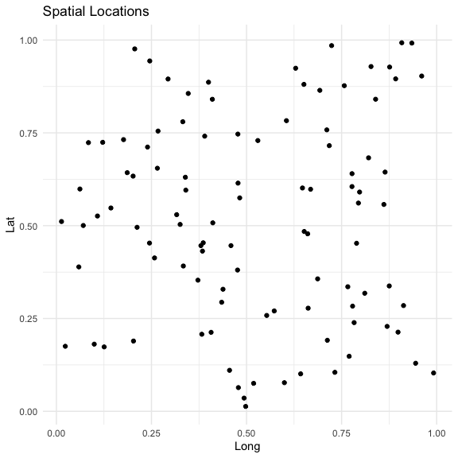

```r
nt <- 200
ns <- 100
set.seed(1)
loc <- data.frame(Long = runif(ns), Lat = runif(ns))
ggplot(loc, aes(x=Long, y =Lat)) +
  geom_point() +
  ggtitle("Spatial Locations") +
  theme_minimal()
```

### Step 2: Create Fixed Effects Covariates (Simulaute Randomly)

```r
X <- array(NA, dim = c(nt, ns, 3))
set.seed(1)
X[,,1] <- matrix(rnorm(nt * ns, sd = sqrt(2)), nrow = nt, ncol = ns)
X[,,2] <- matrix(rnorm(nt * ns, sd = sqrt(1)), nrow = nt, ncol = ns)
X[,,3] <- matrix(rnorm(nt * ns, sd = sqrt(5)), nrow = nt, ncol = ns)
```

### Step 3: Generate Temporal Components

The **`generate_harmonic_matrices`** function from the **`sparseDGLM`** package generates harmonic matrices to model **seasonal temporal dynamics** in a **dynamic linear model (DLM)** framework. This function helps incorporate **cyclical patterns** into time-series models, making it useful for **forecasting and trend analysis** in structured spatiotemporal data.

- **Inputs:**
  - `nt`: Number of time points (here set to `nt=200`)
  - `num_harmonics`: Number of harmonics
  - `period`: Seasonal period (e.g., `7` for weekly seasonality)
- **Outputs:**
  - `Ft.all`: **Design matrix (`Ft`)** capturing seasonal variations.
  - `G.all`: **State transition matrix (`G`)** governing the temporal evolution.

```r
seas.period <- 7
num_harmonics <- 1
details.seas <- sparseDGLM::generate_harmonic_matrices(nt = nt, num_harmonics = num_harmonics, period = seas.period)
Ft <- details.seas$Ft.all
G <- details.seas$G.all
p <- ncol(Ft)
Wt <- diag(c(0.01, 0.02))
```

### Step 4: Simulate Data

The **`sim_synthetic_data`** function from the **`sparseDGLM`** package simulates **synthetic spatiotemporal data** based on a specified **dynamic generalized linear model (DGLM)** framework. This function is useful for simulating synthetic data for **testing and validating** spatiotemporal models before applying them to real-world datasets.

```r
hyper <- list(r = 100, k = 0.5, kappa = 0.35, sigma2 = 0.1, tau2 = 0.05, Wt = Wt) ## model hyperparameters
beta0 <- 1
set.seed(1)
beta <- runif(dim(X)[3])
model <- "dense"
data_lik <- "Poisson"
cor.type <- "Matern1"
sim_data <- sparseDGLM::sim_synthetic_data(
  nt = nt,
  model = model,
  data_lik = data_lik,
  loc = loc,
  hyper = hyper,
  beta0 = beta0,
  beta = beta,
  Wt = Wt,
  X = X,
  Ft = Ft,
  G = G,
  cor.type = cor.type,
  theta0 = rep(0, p),
  mu0 = 6,
  C0 = diag(ns),
  R0 = 0
)
```

### Examine the simulated dataset:

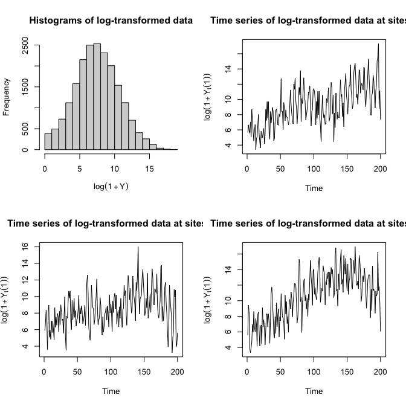

```r
par(mfrow=c(2,2))
hist(log(1+sim_data$y), xlab = expression(log(1+Y)),
     main="Histograms of log-transformed data")
plot(log(1+sim_data$y[,1]), type ="l", xlab="Time", ylab = expression(log(1+Y[t](1))),
     main="Time series of log-transformed data at sites 1")
plot(log(1+sim_data$y[,2]), type ="l", xlab="Time", ylab = expression(log(1+Y[t](1))),
     main="Time series of log-transformed data at sites 2")
plot(log(1+sim_data$y[,3       ]), type ="l", xlab="Time", ylab = expression(log(1+Y[t](1))),
     main="Time series of log-transformed data at sites 3")
```

# Creating Artficially Missing Values to Asses the Prediction Performances

```r
## randomly select the sites where we will remove data partially
set.seed(1)
miss.artfical.na <- sample(1:ns, size = 10, replace = TRUE)
## randomly select the sites where we will completely remove the data sets to asses spatial interpolations
set.seed(1)
spatInt.ind <- sample(setdiff(1:ns, miss.artfical.na), size = 10, replace = TRUE)

Y <- sim_data$y
# Function to generate consecutive missing indices
generate_consecutive_indices <- function(total_days, num_missing) {
  missing_indices <- numeric(0)
  while (length(missing_indices) < num_missing) {
    block_size <- sample(1:min(30, num_missing - length(missing_indices)), 1)
    start <- sample(setdiff(1:total_days, missing_indices), 1)
    block <- start:(start + block_size - 1)
    block <- block[block <= total_days]
    missing_indices <- unique(c(missing_indices, block))
  }
  return(sort(missing_indices[1:num_missing]))
}

missing_range <- c(50, 75) ## range of missing values in each sites
missing_indices <- list()
set.seed(123)
for (site in seq_along(miss.artfical.na)) {
  missing_percentage <- sample(seq(missing_range[1], missing_range[2], by = 1), 1)
  num_missing <- round((missing_percentage / 100) * nt)
  missing_indices[[site]] <- generate_consecutive_indices(nt, num_missing)
  Y[missing_indices[[site]], miss.artfical.na[site]] <- NA
}
```

# MCMC Inference and Predictions

### Step 1: Define Mesh Hyperparameters

In this section we demonstrate the R code that defines **hyperparameters** for constructing a **spatial mesh** using the **Integrated Nested Laplace Approximation (INLA)** framework. This is essential in **spatial modeling**, where the mesh discretizes the study domain to enable efficient inference. The key components are explained below:

#### **1. Mesh Hyperparameter Combinations (`mesh.hyper.comb`)**

- This **list of lists** stores four different **hyperparameter combinations** used to define the spatial mesh.
- Each combination includes:
  - `max.edge`: A vector defining the **maximum edge length** for mesh triangles in the interior and exterior.
  - `cutoff`: The **minimum allowable distance** between two mesh nodes. Smaller values create a denser mesh.
  - `offset`: A vector defining the **outer extension** of the mesh domain.

##### **Example Values:**

```r
list(max.edge = c(2, 2), cutoff = 0.1, offset = c(0.05, 0.2))
```

- Here:
  - `max.edge = c(2, 2)`: The **maximum edge length** of the mesh triangles is 2.
  - `cutoff = 0.1`: Ensures nodes closer than 0.1 units are merged.
  - `offset = c(0.05, 0.2)`: The mesh extends **0.05 units** inward and **0.2 units** outward.

#### **2. Selecting a Mesh Configuration (`mesh.hyper`)**

```r
model_no <- 4
## hyper-parameter used for four different combinations of mesh nodes construction
mesh.hyper.comb <- list(
  list(max.edge = c(2, 2), cutoff = 0.1, offset = c(0.05, 0.2)),
  list(max.edge = c(2, 2), cutoff = 0.06, offset = c(0.05, 0.2)),
  list(max.edge = c(2, 2), cutoff = 0.04, offset = c(0.05, 0.2)),
  list(max.edge = c(2, 2), cutoff = 0.03, offset = c(0.05, 0.2))
)
mesh.hyper <- mesh.hyper.comb[[model_no]]
```

- `model_no = 4`: Selects the **fourth** hyperparameter combination from `mesh.hyper.comb`.
- `mesh.hyper`: Stores the corresponding **mesh parameter settings**.

#### **3. Mesh Construction (`INLA::inla.mesh.2d`)**

```r
INLA.mesh <- INLA::inla.mesh.2d(
  loc = as.matrix(loc),
  max.edge = mesh.hyper$max.edge,
  cutoff = mesh.hyper$cutoff,
  offset = mesh.hyper$offset
)
```

- **Purpose**: Creates a **spatial triangulation mesh** over the study region.
- **Inputs:**
  - `loc`: Matrix of **spatial locations** (site coordinates).
  - `max.edge`: Maximum triangle edge length (from `mesh.hyper`).
  - `cutoff`: Minimum node spacing (from `mesh.hyper`).
  - `offset`: Mesh extension boundary (from `mesh.hyper`).
- **Output**: `INLA.mesh`, an object containing the **triangulated mesh**.

#### **4. Projection Matrix (`A.proj`)**

```r
A.proj <- inla.spde.make.A(mesh = INLA.mesh, loc = as.matrix(loc))
```

- **Purpose**: Projects the observation locations onto the mesh for **spatial interpolation**.
- **Input**:
  - `mesh`: The generated **INLA mesh**.
  - `loc`: The **spatial locations**.
- **Output**: `A.proj`, a matrix mapping observation locations to mesh nodes.
- **Dimension Check**:

  ```r
  dim(A.proj)[2]
  ```

  - Returns the number of **mesh nodes**.

#### **5. Plotting the Spatial Mesh**

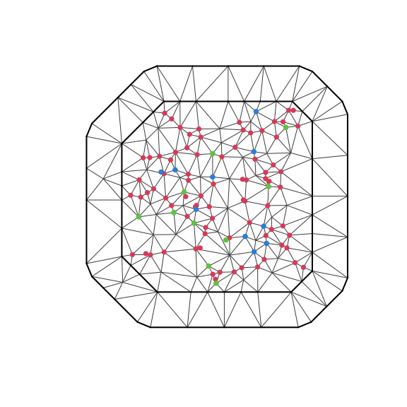

```r
par(mfrow=c(1,1))
plot(INLA.mesh)
points(loc, col=2, cex=1, pch=16)
points(loc[spatInt.ind,], col=3, cex=1, pch=16)
points(loc[miss.artfical.na,], col=4, cex=1, pch=16)
```

### Step 2: Run MCMC Sampler

- **`X`**: The design matrix of dimension `n x T x q`, where `q` represents the number of fixed effects covariates. This matrix includes the fixed effects coefficients used in the model.
- **`loc`**: A matrix of spatial coordinates with dimensions `n x 2`, where each row corresponds to a spatial location.
- **`num_harmonics`**: The number of harmonic terms used to model the seasonal components in the data.
- **`seas.period`**: The seasonal period defining the time interval for periodicity in the data.
- **`model`**: Specifies the type of model to be used. In this case, `"sparse"` indicates that a sparse model structure is being employed.
- **`data_lik`**: The likelihood function for the observed data, defining the assumed statistical distribution for the response variable.
- **`cor.type`**: The type of spatial correlation structure used in the model, such as Matérn or exponential covariance.
- **`spatInt.ind`**: An index or indicator specifying which spatial locations are included in the spatial interaction terms.
- **`forcast.ind`**: A vector specifying the indices of future time points for which predictions or forecasts will be generated. In this case, it is set to `1:7`, meaning predictions for the next 7 time steps.
- **`N.MCMC`**: The total number of MCMC iterations to be performed in the sampler.
- **`samples.store`**: The number of posterior samples to be stored for further analysis.
- **`mesh.hyper`**: A hyperparameter setting related to the spatial mesh used in the model, which is selected from a predefined combination of mesh configurations.
- **`print.result`**: A logical value (`TRUE` or `FALSE`) indicating whether to print summary results during the MCMC process.
- **`traceplot`**: A logical value (`TRUE` or `FALSE`) specifying whether to generate trace plots of the sampled posterior parameters to assess convergence.
- **`simulation`**: A logical value (`TRUE` or `FALSE`) indicating whether the function is being run on simulated data.
- **`no_parallel_chain`**: Specifies the number of parallel MCMC chains to be executed simultaneously.

```r
start_time <- Sys.time()
mcmc.output <- sparseDGLM::MCMC.sampler.st.DGLM(
  Y = Y,
  X = X,
  loc = loc,
  num_harmonics = num_harmonics,
  seas.period = seas.period,
  model = "sparse",
  data_lik = data_lik,
  cor.type = cor.type,
  spatInt.ind = spatInt.ind,
  forcast.ind = 1:7,
  N.MCMC = 500,
  samples.store = 100,
  mesh.hyper = mesh.hyper.comb[[4]],
  print.result = FALSE,
  traceplot = FALSE,
  simulation = TRUE,
  no_parallel_chain = 1
)
end_time <- Sys.time()
run_time <- end_time - start_time
run_time
```

```
#> Time difference of 1.328462 mins
```

# Step 3: Extracting the Outputs

### Posterior Summary of Hyperparameters

This **extracts the posterior summary of model hyperparameters** estimated from the MCMC sampling process. The summary typically includes:

- **Posterior mean** and **credible intervals** for key model parameters.
- **Variance components**, such as:
  - `sigma2`: Process variance controlling temporal dynamics.
  - `tau2`: Measurement error variance.
- **Spatial dependence parameters**, such as:
  - `kappa`: Range parameter governing spatial correlation.
  - `rho`: Temporal autocorrelation parameter.
- **Fixed effect estimates**, including:
  - `beta0`: Intercept.
  - `beta`: Regression coefficients for covariates.
- **Harmonic component parameters**, if applicable.

```r
mcmc.output$summery.hyper
```

```
#> $sumry.hyper
#>                             mean     median         std   quant2.5  quant97.5
#> kappa (spat. range)   27.6762413 27.9216113 1.693018284 25.1961131 30.0008499
#> sigma2 (var. intcpt.)  0.1333196  0.1319755 0.006505849  0.1238363  0.1416304
#> tau2 (var.nugget)      0.1950011  0.1940612 0.004423885  0.1880285  0.2013340
#>
#> $sumry.var.state
#>            mean     median         std   quant2.5  quant97.5
#> phi1 0.04105978 0.03866234 0.006729609 0.03275881 0.05150430
#> phi2 0.03658507 0.02951993 0.013483879 0.02419006 0.05928208
```

### Posterior Summary of Fixed Effects Coeffiecients

This **extracts the posterior summary of fixed effect coefficients** estimated from the MCMC sampling process. The summary includes:

This output helps in assessing the **significance** of the fixed effects in the **spatiotemporal dynamic model**, providing key insights into the influence of covariates.

```r
mcmc.output$summary.fixed.effects.coeff
```

```
#> $overall.intcp
#> NULL
#>
#> $cov.coeff
#>            mean    median         std  quant2.5 quant97.5
#> beta1 0.2476657 0.2476102 0.001333925 0.2460108 0.2501307
#> beta2 0.3442381 0.3443589 0.002261710 0.3410776 0.3475210
#> beta3 0.5389969 0.5393280 0.001409072 0.5365994 0.5408098
```

### Extracting Posterior Estimates of Spatiotemporal Intercepts

This section demonstrate to extracts and visualizes the **spatiotemporal intercept estimates** from the MCMC sampling process. The spatiotemporal intercept **$\mu_t(s)$** represents the evolving baseline trend at different spatial locations over time.

```r
intcp_est_dense <- mcmc.output$summary.st.intercepot$mu.st$mean
intcp_lci_dense <- mcmc.output$summary.st.intercepot$mu.st$quant2.5
intcp_uci_dense <- mcmc.output$summary.st.intercepot$mu.st$quant97.5
intcp_true <- sim_data$mu.st[1:mcmc.output$nt, -mcmc.output$spatInt.ind]
```

- `intcp_est_dense`: **Posterior mean** of spatiotemporal intercepts.
- `intcp_lci_dense`: **Lower bound (2.5% quantile)** of the credible interval.
- `intcp_uci_dense`: **Upper bound (97.5% quantile)** of the credible interval.

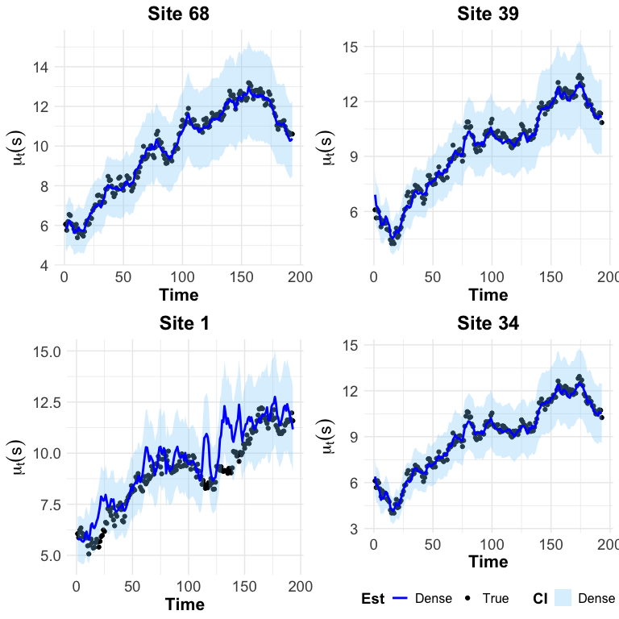

```r
set.seed(1)
select.ind <- sample(1:ncol(intcp_true), size = 4, replace = FALSE)
plot_list <- list()
for (i in seq_along(select.ind)) {
  idx <- select.ind[i]
  data <- data.frame(
    Time = 1:nrow(intcp_true),
    True = intcp_true[, idx],
    Dense_Est = intcp_est_dense[, idx],
    Dense_LCI = intcp_lci_dense[, idx],
    Dense_UCI = intcp_uci_dense[, idx]
  )
  # Create ggplot
  p <- ggplot(data, aes(x = Time)) +
    geom_point(aes(y = True, color = "True"), size = 1.5) +
    geom_ribbon(aes(ymin = Dense_LCI, ymax = Dense_UCI, fill = "Dense"), alpha = 0.3) +
    geom_line(aes(y = Dense_Est, color = "Dense"), size = 1) +
    labs(
      title = paste0("Site ", idx),
      y = expression(mu[t](s)),
      x = "Time",
      color = "Est",
      fill = "CI"
    ) +
    scale_color_manual(values = c("True" = "black", "Dense" = "blue")) +
    scale_fill_manual(values = c("Dense" = "#87CEFA")) +
    theme_minimal() +
    theme(
      legend.position = ifelse(i == length(select.ind), "bottom", "none"),
      plot.title = element_text(size = 18, face = "bold", hjust = 0.5),
      axis.title = element_text(size = 16, face = "bold"),
      axis.text = element_text(size = 14),
      legend.title = element_text(size = 14, face = "bold"),
      legend.text = element_text(size = 12),
      plot.caption = element_text(size = 12, hjust = 0.5)
    )

  plot_list[[i]] <- p
}
g <- grid.arrange(grobs = plot_list, ncol = 2)
```

```r
g
```

- **True values (black points)**: Represent actual intercept values.
- **Estimated intercepts (blue line)**: Show posterior mean estimates.
- **Shaded region (credible interval)**: Represents model uncertainty.

```r
intcp_est_dense <- mcmc.output$summary.st.intercepot$mu.st$mean
intcp_lci_dense <- mcmc.output$summary.st.intercepot$mu.st$quant2.5
intcp_uci_dense <- mcmc.output$summary.st.intercepot$mu.st$quant97.5
intcp_true <- sim_data$mu.st[1:mcmc.output$nt, -mcmc.output$spatInt.ind]
```

### Spatial Interpolations (Krigging)

This section **evaluates the spatial interpolation (kriging) results** by comparing predicted values with true values at spatial integration sites. Kriging is a method used to estimate values at **unobserved spatial locations** based on **observed data**.

```r
spatintpl_est_dense <- mcmc.output$predictions$spatial$median
spatintpl_lci_dense <- mcmc.output$predictions$spatial$quant2.5
spatintpl_uci_dense <- mcmc.output$predictions$spatial$quant97.5
spatintpl_true <- sim_data$y[1:mcmc.output$nt, mcmc.output$spatInt.ind]
```

- `spatintpl_est_dense`: **Median prediction** for spatial interpolation.
- `spatintpl_lci_dense`: **Lower bound (2.5% quantile)** of the **credible interval**.
- `spatintpl_uci_dense`: **Upper bound (97.5% quantile)** of the **credible interval**.
- `spatintpl_true`: **true observed values** $Y_t(s)$ at the given spatial sites.

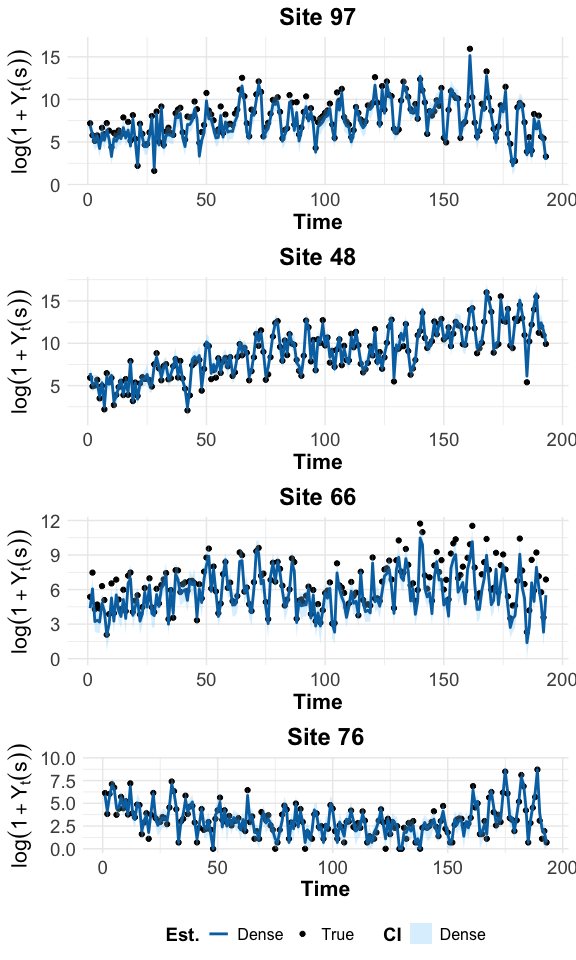

```r
set.seed(2)
select.ind <- sample(1:length(mcmc.output$spatInt.ind), size = 4, replace = FALSE)
plot_list <- list()
for (i in seq_along(select.ind)) {
  idx <- select.ind[i]
  data <- data.frame(
    Time = 1:nrow(spatintpl_true),
    True = log(1 + spatintpl_true[, idx]),
    Dense_Est = log(1 + spatintpl_est_dense[, idx]),
    Dense_LCI = log(1 + spatintpl_lci_dense[, idx]),
    Dense_UCI = log(1 + spatintpl_uci_dense[, idx])
  )

  # Create ggplot for each site
  p <- ggplot(data, aes(x = Time)) +
    geom_point(aes(y = True, color = "True"), size = 1.5) +
    geom_ribbon(aes(ymin = Dense_LCI, ymax = Dense_UCI, fill = "Dense"), alpha = 0.3) +
    geom_line(aes(y = Dense_Est, color = "Dense"), size = 1) +
    labs(
      title = paste0("Site ", mcmc.output$spatInt.ind[idx]),
      y = expression(log(1+Y[t](s))),
      x = "Time",
      color = "Est.",
      fill = "CI"
    ) +
    scale_color_manual(values = c("True" = "black", "Dense" = "#0072B2")) +
    scale_fill_manual(values = c("Dense" = "#87CEFA")) +
    theme_minimal() +
    theme(
      legend.position = ifelse(i == length(select.ind), "bottom", "none"),
      plot.title = element_text(size = 18, face = "bold", hjust = 0.5),
      axis.title = element_text(size = 16, face = "bold"),
      axis.text = element_text(size = 14),
      legend.title = element_text(size = 14, face = "bold"),
      legend.text = element_text(size = 12)
    )

  plot_list[[i]] <- p
}
g <- grid.arrange(grobs = plot_list, ncol = 1)
```

```r
g
```

### Future Forecasting

This section evaluates the **future predictions** generated by the model for **unobserved time points** beyond the training period. The **forecasting results** are compared with the true values from simulated data, focusing on uncertainty quantification using posterior distributions.

```r
spatintpl_est_dense <- mcmc.output$predictions$forecast$median
spatintpl_lci_dense <- mcmc.output$predictions$forecast$quant2.5
spatintpl_uci_dense <- mcmc.output$predictions$forecast$quant97.5
spatintpl_true <- sim_data$y[-(1:mcmc.output$nt), -mcmc.output$spatInt.ind]
```

- `spatintpl_est_dense`: **Median posterior prediction** for future values.
- `spatintpl_lci_dense`: **Lower bound (2.5% quantile)** of the **credible interval**.
- `spatintpl_uci_dense`: **Upper bound (97.5% quantile)** of the **credible interval**.

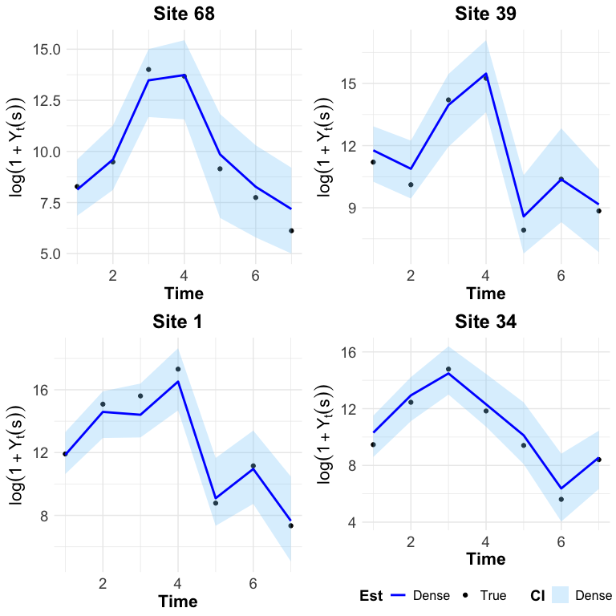

```r
set.seed(1)
select.ind <- sample(1:mcmc.output$ns, size = 4, replace = FALSE)
plot_list <- list()
for (i in seq_along(select.ind)) {
  idx <- select.ind[i]
  data <- data.frame(
    Time = 1:nrow(spatintpl_true),
    True = log(1 + spatintpl_true[, idx]),
    Dense_Est = log(1 + spatintpl_est_dense[, idx]),
    Dense_LCI = log(1 + spatintpl_lci_dense[, idx]),
    Dense_UCI = log(1 + spatintpl_uci_dense[, idx])
  )

  # Create ggplot for each site
  p <- ggplot(data, aes(x = Time)) +
    geom_point(aes(y = True, color = "True"), size = 1.5) +  # Slightly larger points
    geom_ribbon(aes(ymin = Dense_LCI, ymax = Dense_UCI, fill = "Dense"), alpha = 0.3) +
    geom_line(aes(y = Dense_Est, color = "Dense"), size = 1) +
    labs(
      title = paste0("Site ", idx),
      y = expression(log(1+Y[t](s))),
      x = "Time",
      color = "Est",
      fill = "CI"
    ) +
    scale_color_manual(values = c("True" = "black","Dense" = "blue")) +
    scale_fill_manual(values = c("Dense" = "#87CEFA")) +
    theme_minimal() +
    theme(
      legend.position = ifelse(i == length(select.ind), "bottom", "none"),
      plot.title = element_text(size = 18, face = "bold", hjust = 0.5),  # Larger title
      axis.title = element_text(size = 16, face = "bold"),               # Larger axis titles
      axis.text = element_text(size = 14),                              # Larger axis text
      legend.title = element_text(size = 14, face = "bold"),            # Larger legend title
      legend.text = element_text(size = 12),                            # Larger legend text
      plot.caption = element_text(size = 12, hjust = 0.5)               # Larger captions
    )

  plot_list[[i]] <- p
}
g <- grid.arrange(grobs = plot_list, ncol = 2)
```

```r
g
```

### Spatiotemproal Prediction

This section evaluates the **spatiotemporal predictions** by comparing the model’s posterior predictions with true values across both **space and time**. The focus is on estimating the **evolution of values at specific spatial locations over future time points**.

```r
spatintpl_est_dense <- mcmc.output$predictions$space.time$median
spatintpl_lci_dense <- mcmc.output$predictions$space.time$quant2.5
spatintpl_uci_dense <- mcmc.output$predictions$space.time$quant97.5
spatintpl_true <- sim_data$y[-(1:mcmc.output$nt), mcmc.output$spatInt.ind]
```

- `spatintpl_est_dense`: **Posterior median estimate** for spatiotemporal predictions.
- `spatintpl_lci_dense`: **Lower bound (2.5% quantile)** of the **credible interval**.
- `spatintpl_uci_dense`: **Upper bound (97.5% quantile)** of the **credible interval**.

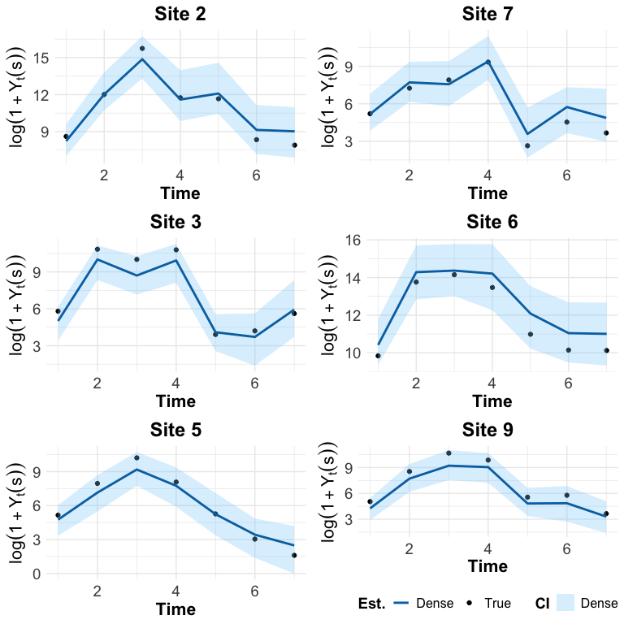

```r
set.seed(12)
select.ind <- sample(1:length(mcmc.output$spatInt.ind), size = 6, replace = FALSE)
plot_list <- list()
for (i in seq_along(select.ind)) {
  idx <- select.ind[i]
  data <- data.frame(
    Time = 1:nrow(spatintpl_true),
    True = log(1 + spatintpl_true[, idx]),
    Dense_Est = log(1 + spatintpl_est_dense[, idx]),
    Dense_LCI = log(1 + spatintpl_lci_dense[, idx]),
    Dense_UCI = log(1 + spatintpl_uci_dense[, idx])
  )
  p <- ggplot(data, aes(x = Time)) +
    geom_point(aes(y = True, color = "True"), size = 1.5) +
    geom_ribbon(aes(ymin = Dense_LCI, ymax = Dense_UCI, fill = "Dense"), alpha = 0.3) +
    geom_line(aes(y = Dense_Est, color = "Dense"), size = 1) +
    labs(
      title = paste0("Site ", idx),
      y = expression(log(1+Y[t](s))),
      x = "Time",
      color = "Est.",
      fill = "CI"
    ) +
    scale_color_manual(values = c("True" = "black", "Dense" = "#0072B2")) +
    scale_fill_manual(values = c("Dense" = "#87CEFA")) +
    theme_minimal() +
    theme(
      legend.position = ifelse(i == length(select.ind), "bottom", "none"),
      plot.title = element_text(size = 18, face = "bold", hjust = 0.5),  # Larger, bold title
      axis.title = element_text(size = 16, face = "bold"),               # Larger axis titles
      axis.text = element_text(size = 14),                              # Larger axis text
      legend.title = element_text(size = 14, face = "bold"),            # Larger legend title
      legend.text = element_text(size = 12)                             # Larger legend text
    )

  plot_list[[i]] <- p
}
g <- grid.arrange(grobs = plot_list, ncol = 2)
```

```r
g
```

### Coefficents of Dynamic Temproal Components

This section evaluates the **dynamic temporal coefficients** ($\theta_t$), comparing the model’s posterior estimates with the true underlying values. These coefficients represent **time-evolving effects** that capture temporal dependencies in the model.

```r
est.temp.eff <- mcmc.output$summary.dynamic.temp.coeff$mean
lci.temp.eff <- mcmc.output$summary.dynamic.temp.coeff$quant2.5
uci.temp.eff <- mcmc.output$summary.dynamic.temp.coeff$quant97.5
true.temp.eff <- sim_data$theta[1:mcmc.output$nt, ]
```

- `est.temp.eff`: **Posterior mean estimate** of the temporal coefficients.
- `lci.temp.eff`: **Lower bound (2.5% quantile)** of the **credible interval**.
- `uci.temp.eff`: **Upper bound (97.5% quantile)** of the **credible interval**.

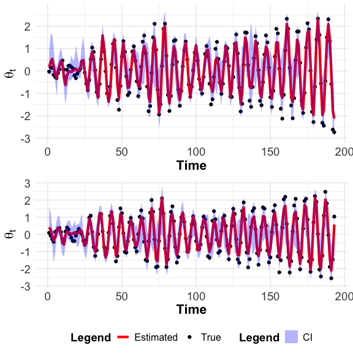

```r
plot_list <- list()
for (i in 1:ncol(true.temp.eff)) {
  data <- data.frame(
    Time = 1:nrow(true.temp.eff),
    True = true.temp.eff[, i],
    Est = est.temp.eff[, i],
    LCI = lci.temp.eff[, i],
    UCI = uci.temp.eff[, i]
  )
  ran <- c(
    min(data$True, data$Est, data$LCI, data$UCI, na.rm = TRUE),
    max(data$True, data$Est, data$LCI, data$UCI, na.rm = TRUE)
  )
  p <- ggplot(data, aes(x = Time)) +
    geom_point(aes(y = True, color = "True"), size = 1.5) +
    geom_line(aes(y = Est, color = "Estimated"), size = 1.5) +
    geom_ribbon(aes(ymin = LCI, ymax = UCI, fill = "CI"), alpha = 0.3) +
    scale_color_manual(values = c("True" = "black", "Estimated" = "red")) +
    scale_fill_manual(values = c("CI" = "blue")) +
    labs(
      y = expression(theta[t]),
      x = "Time",
      color = "Legend",
      fill = "Legend"
    ) +
    coord_cartesian(ylim = ran) +
    theme_minimal() +
    theme(
      legend.position = ifelse(i == ncol(true.temp.eff), "bottom", "none"),
      plot.title = element_text(size = 18, face = "bold", hjust = 0.5),
      axis.title = element_text(size = 16, face = "bold"),
      axis.text = element_text(size = 14),
      legend.title = element_text(size = 14, face = "bold"),
      legend.text = element_text(size = 12)
    )

  plot_list[[i]] <- p
}
g <- grid.arrange(grobs = plot_list, ncol = 1)
```

```r
g
```